**Regression and Classification**

|  | by Prof. Seungchul Lee Industrial AI Lab http://isystems.unist.ac.kr/ POSTECH |
| --- | --- |

Table of Contents

# 1. Regression

- $\hat y_i = f(x_i, \theta)$ in general
- In many cases, a linear model to predict $y_i$ is assumed

$\text{Given} \; \begin{cases} x_{i} \; \text{: inputs} \\ y_{i} \; \text{: outputs} \end{cases}$ , Find $\theta_{1}$ and $\theta_{2}$

$$x= \begin{bmatrix} x_{1} \\ x_{2} \\ \vdots \\ x_{m} \end{bmatrix}, \qquad y= \begin{bmatrix} y_{1} \\ y_{2} \\ \vdots \\ y_{m} \end{bmatrix} \approx \hat{y}_{i} = \theta_{1}x_{i} + \theta_{2} $$

- $ \hat{y}_{i} $ : predicted output
- $ \theta = \begin{bmatrix} \theta_{1} \\ \theta_{2} \\ \end{bmatrix} $ : Model parameters

$$ \hat{y}_{i} = f(x_{i}, \theta) \; \text{ in general}$$

- in many cases, a linear model to predict $y_{i}$ used

$$ \hat{y}_{i} = \theta_{1}x_{i} + \theta_{2} \; \text{ such that } \min\limits_{\theta_{1}, \theta_{2}}\sum\limits_{i = 1}^{m} (\hat{y}_{i} - y_{i})^2$$

[figure not shown]

- How to find model parameters, $\theta = \begin{bmatrix}\theta_{1} \\ \theta_{2}\end{bmatrix}$

$$x = \begin{bmatrix} x_1 \\ x_2 \\ \vdots \\ x_m \end{bmatrix}, \quad y = \begin{bmatrix} y_1 \\ y_2 \\ \vdots \\ y_m \end{bmatrix} \approx \hat y_i = \theta_1 x_i + \theta_2$$$$\hat y_i = \theta_1 x_i + \theta_2 \quad \text{such that} \ \min_{\theta_1,\theta_2} \sum^m_{\theta_1, \theta_2} (\hat y_i - y_i)^2$$

**Regression**

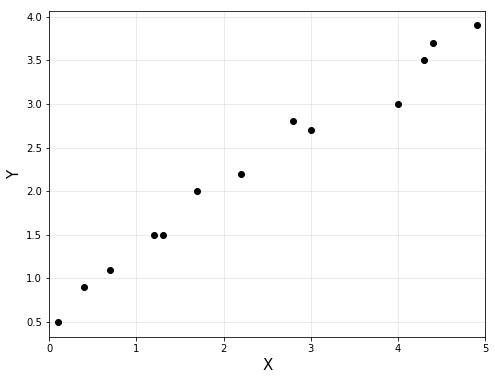

```python
import numpy as np
import matplotlib.pyplot as plt

# data points in column vector [input, output]
x = np.array([0.1, 0.4, 0.7, 1.2, 1.3, 1.7, 2.2, 2.8, 3.0, 4.0, 4.3, 4.4, 4.9]).reshape(-1, 1)
y = np.array([0.5, 0.9, 1.1, 1.5, 1.5, 2.0, 2.2, 2.8, 2.7, 3.0, 3.5, 3.7, 3.9]).reshape(-1, 1)

# to plot
plt.figure(figsize=(10, 6))
plt.plot(x, y, 'ko', label="data")
plt.xlabel('X', fontsize=15)
plt.ylabel('Y', fontsize=15)
plt.axis('scaled')
plt.grid(alpha=0.3)
plt.xlim([0, 5])
plt.show()
```

**CVXPY**

- Use CVXPY optimization (least-squared)
  - For convenience, we define a function that maps inputs to feature vectors, 𝜙

$\hat{y}_i = \begin{bmatrix} x_i & 1 \end{bmatrix} \begin{bmatrix}\theta_{1} \\ \theta_{2}\end{bmatrix} \\ =\begin{bmatrix} x_i \\ 1\end{bmatrix}^T\begin{bmatrix}\theta_{1} \\ \theta_{2}\end{bmatrix} \qquad \qquad \qquad \text{feature vector} \phi(x_i) = \begin{bmatrix} x_i \\ 1\end{bmatrix} \\ = \phi^T (x_i) \theta $

$\Phi = \begin{bmatrix} x_1 & 1 \\ x_2 & 1 \\ \vdots & \vdots \\ x_m & 1 \end{bmatrix} = \begin{bmatrix} \phi^T(x_1) \\ \phi^T(x_2) \\ \vdots \\ \phi^T(x_m) \end{bmatrix} \quad \Longrightarrow \quad \hat{y} = \begin{bmatrix} \hat{y_1} \\ \hat{y_2} \\ \vdots \\ \hat{y_m} \end{bmatrix} = \Phi \theta $

**parameter Estimation**

- Model parameter estimation

$$\min_\theta \, \lVert \hat{y}-y \rVert_2 = \min_\theta \, \lVert A\theta -y \rVert_2$$

```python
import cvxpy as cvx

m = y.shape[0]
#A = np.hstack([x, np.ones([m, 1])])
A = np.hstack([x, x**0])
A = np.asmatrix(A)

theta2 = cvx.Variable(2, 1)
obj = cvx.Minimize(cvx.norm(A*theta2-y, 2))
cvx.Problem(obj,[]).solve()

print('theta:\n', theta2.value)
```

```
theta:
 [[0.67129519]
 [0.65306531]]
```

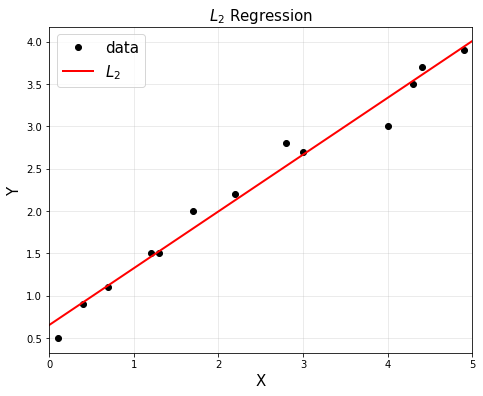

```python
# to plot
plt.figure(figsize=(10, 6))
plt.title('$L_2$ Regression', fontsize=15)
plt.xlabel('X', fontsize=15)
plt.ylabel('Y', fontsize=15)
plt.plot(x, y, 'ko', label="data")

# to plot a straight line (fitted line)
xp = np.arange(0, 5, 0.01).reshape(-1, 1)
theta2 = theta2.value
yp = theta2[0,0]*xp + theta2[1,0]

plt.plot(xp, yp, 'r', linewidth=2, label="$L_2$")
plt.legend(fontsize=15)
plt.axis('scaled')
plt.grid(alpha=0.3)
plt.xlim([0, 5])
plt.show()
```

# 2. Classification

- Perceptron: make use of sign of data
  - discuss it later
- Logistic regression is a classification algorithm
  - don't be confused
- To find a classification boundary

[figure not shown]

**Sign**

- Sign with respect to a line

$$\omega=\begin{bmatrix} \omega_1 \\ \omega_2 \end{bmatrix},\quad \omega=\begin{bmatrix} \omega_1 \\ \omega_2 \end{bmatrix}\quad \Longrightarrow g(x)=\omega_1 x_1+\omega_2 x_2+\omega_0=\omega^T x+\omega_0$$$$\omega=\begin{bmatrix} \omega_0 \\ \omega_1 \\ \omega_2 \end{bmatrix},\quad \omega=\begin{bmatrix} 1 \\ \omega_1 \\ \omega_2 \end{bmatrix}\quad \Longrightarrow g(x)=\omega_0 + \omega_1 x_1+\omega_2 x_2=\omega^T x$$

[figure not shown]

**Perceptron**

[figure not shown]

- Hyperplane
  - Separates a D-dimensional space into two half-spaces
  - Defined by an outward pointing normal vector
  - $\omega$ is orthogonal to any vector lying on the hyperplane

[figure not shown]

**How to Find $\omega$**

- All data in class 1
  - $g(\omega^T x)>0$
- All data in class 0
  - $g(\omega^T x)<0$

[figure not shown]

**Perceptron Algorithm**

- The perceptron implements

$$h(x) = \text{sign}\left( \omega^Tx \right)$$

- Given the training set

$$(x_1, y_1), (x_2, y_2), \cdots, (x_N, y_N) \quad \text{where } y_i \in \{-1,1\}$$

```
1) pick a misclassified point
```

$$ \text{sign}\left(\omega^Tx_n \right) \neq y_n$$

```
2) and update the weight vector
```

$$\omega \leftarrow \omega + y_nx_n$$

[figure not shown]

- Why perceptron updates work ?
- Let's look at a misclassified positive example ($y_n = +1$)
  - perceptron (wrongly) thinks $\omega_{old}^T x_n < 0$
- updates would be $$ \begin{align*}\omega_{new} &= \omega_{old} + y_n x_n = \omega_{old} + x_n \\ \\ \omega_{new}^T x_n &= (\omega_{old} + x_n)^T x_n = \omega_{old}^T x_n + x_n^T x_n \end{align*}$$
- Thus $\omega_{new}^T x_n$ is less negative than $\omega_{old}^T x_n$

## Python Example

```python
import numpy as np
import matplotlib.pyplot as plt

% matplotlib inline
```

```python
#training data gerneration
m = 100
x1 = 8*np.random.rand(m, 1)
x2 = 7*np.random.rand(m, 1) - 4

g0 = 0.8*x1 + x2 - 3
g1 = g0 - 1
g2 = g0 + 1
```

```python
C1 = np.where(g1 >= 0)
C2 = np.where(g2 < 0)
print(C1)
```

```
(array([ 2,  8, 10, 11, 16, 21, 22, 26, 27, 36, 38, 42, 44, 48, 53, 57, 61,
       62, 74, 79, 83, 86, 87, 89, 90, 96, 99], dtype=int64), array([0, 0, 0, 0, 0, 0, 0, 0, 0, 0, 0, 0, 0, 0, 0, 0, 0, 0, 0, 0, 0, 0,
       0, 0, 0, 0, 0], dtype=int64))
```

```python
C1 = np.where(g1 >= 0)[0]
C2 = np.where(g2 < 0)[0]
print(C1.shape)
print(C2.shape)
```

```
(27,)
(54,)
```

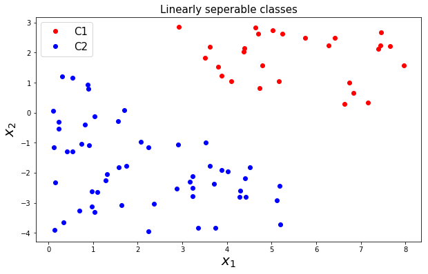

```python
plt.figure(figsize=(10, 6))
plt.plot(x1[C1], x2[C1], 'ro', label='C1')
plt.plot(x1[C2], x2[C2], 'bo', label='C2')
plt.title('Linearly seperable classes', fontsize=15)
plt.legend(loc='upper left', fontsize=15)
plt.xlabel(r'$x_1$', fontsize=20)
plt.ylabel(r'$x_2$', fontsize=20)
plt.show()
```

$$ \begin{align*} \omega = \begin{bmatrix} \omega_1 \\ \omega_2 \\ \omega_3 \\ \end{bmatrix} \qquad \qquad x &= \begin{bmatrix} \left(x^{(1)}\right)^T \\ \left(x^{(2)}\right)^T \\ \left(x^{(3)}\right)^T\\ \vdots \\ \left(x^{(m)}\right)^T \end{bmatrix} = \begin{bmatrix} 1 & x_1^{(1)} & x_2^{(1)} \\ 1 & x_1^{(2)} & x_2^{(2)} \\ 1 & x_1^{(3)} & x_2^{(3)}\\\vdots & \vdots & \vdots \\ 1 & x_1^{(m)} & x_2^{(m)}\end{bmatrix} \\ y &= \begin{bmatrix}y^{(1)} \\ y^{(2)} \\ y^{(3)}\\ \vdots \\ y^{(m)} \end{bmatrix} \end{align*}$$

```python
X1 = np.hstack([np.ones([C1.shape[0],1]), x1[C1], x2[C1]])
X2 = np.hstack([np.ones([C2.shape[0],1]), x1[C2], x2[C2]])
X = np.vstack([X1, X2])

y = np.vstack([np.ones([C1.shape[0],1]), -np.ones([C2.shape[0],1])])

X = np.asmatrix(X)
y = np.asmatrix(y)
```

$$\omega = \begin{bmatrix} \omega_1 \\ \omega_2 \\ \omega_3\end{bmatrix}$$$$\omega \leftarrow \omega + yx$$

where $(x, y)$ is a misclassified training point

```python
w = np.ones([3,1])
w = np.asmatrix(w)

n_iter = y.shape[0]
for k in range(n_iter):
    for i in range(n_iter):
        if y[i,0] != np.sign(X[i,:]*w)[0,0]:
            w += y[i,0]*X[i,:].T

print(w)
```

```
[[-11.        ]
 [  2.05983422]
 [  7.00620838]]
```

$$ \begin{align*} g(x) &= \omega^Tx + \omega_0 = \omega_1x_1 + \omega_2x_2 + \omega_0 = 0 \\ \implies x_2 &= -\frac{\omega_1}{\omega_2} x_1 - \frac{\omega_0}{\omega_2} \end{align*} $$

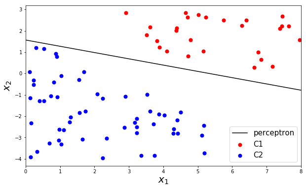

```python
x1p = np.linspace(0,8,100).reshape(-1,1)
x2p = - w[1,0]/w[2,0]*x1p - w[0,0]/w[2,0]

plt.figure(figsize=(10, 6))
plt.scatter(x1[C1], x2[C1], c='r', s=50, label='C1')
plt.scatter(x1[C2], x2[C2], c='b', s=50, label='C2')
plt.plot(x1p, x2p, c='k', label='perceptron')
plt.xlim([0,8])
plt.xlabel('$x_1$', fontsize = 20)
plt.ylabel('$x_2$', fontsize = 20)
plt.legend(loc = 4, fontsize = 15)
plt.show()
```

**Perceptron**

[figure not shown]

**Using Distances**

[figure not shown]

$$\left\vert h_1 \right\vert+\left\vert h_2 \right\vert \qquad \qquad \qquad \qquad \left\vert h_1 \right\vert+\left\vert h_2 \right\vert\\ \left\vert h_1 \right\vert\bullet\left\vert h_2 \right\vert \qquad \qquad \qquad \qquad \left\vert h_1 \right\vert\bullet\left\vert h_2 \right\vert\\ {\left\vert h_1 \right\vert+\left\vert h_2 \right\vert\over 2} \ge \sqrt{\left\vert h_1 \right\vert\bullet\left\vert h_2 \right\vert} \qquad \text{equal iff} \, \left\vert h_1 \right\vert = \left\vert h_2 \right\vert$$

## Using all Distances

- basic idea: to find the decision boundary (hyperplane) of $g(x)=\omega^T x = 0$ such that maximizes $\prod_i \vert h_i \vert \rightarrow$ ${\color{Red}{\text{optimization}}}$

[figure not shown]

- Inequality of arithmetic and geometric means $${x_1 + x_2 + \dots + x_m \over m} \ge \sqrt[m]{x_1 \cdot x_2 \dots x_m}$$ and that equality holds if and only if $x_1=x_2=\dots=x_m$
- Roughly speaking, this optimization of $\max \prod_i \vert h_i \vert$ tends to position a hyperplane in the middle of two classes

**Distance from a Line: h**

- for any vector of $x$

[figure not shown]

  $$\therefore \quad h = {g(x) \over \Vert \omega \Vert} \implies \text{orthogonal distance from the line}$$

$$h = {g(x) \over \Vert \omega \Vert} = {\omega^T x \over \Vert \omega \Vert} \sim \omega^T x$$

## Using all Distances with Outliers

- Logistic Regression

[figure not shown]

**Sigmoid Function**

- We link or squeeze (−$\infty$,+$\infty$) to (0, 1) for several reasons:

[figure not shown]

$\sigma$(𝑧) is the sigmoid function, or the logistic function

- logistic function always generates a value between 0 and 1
- Crosses 0.5 at the origin, then flattens out

$$\sigma (z) = {1\over{1+e^{-z}}} \implies \sigma(\omega^T x)={1 \over{1+e^{-\omega^T x}}}$$

[figure not shown]

- Benefit of mapping via the logistic function
  - monotonic: same or similar optimziation solution
  - continuous and differentiable: good for gradient descent optimization
  - probability or confidence: can be considered as probability

  $$P\left(y = +1 \mid x,\omega\right) = \frac{1}{1+e^{-\omega^T x}} \;\; \in \; [0,1]$$
- Goal: we need to fit $\omega$ to our data $$\max \prod_i \vert h_i \vert$$
- Again, it is an optimization problem

# Logistic Regression

- Classified based on probability

[figure not shown]

## 3.1. Multiclass Classification: Softmax

- Generalization to more than 2 classes is straightforward
  - one vs. all (one vs. rest)
  - one vs. one
- Using the soft-max function instead of the logistic function (refer to [UFLDL Tutorial](http://ufldl.stanford.edu/tutorial/supervised/SoftmaxRegression/))
  - see them as probability

$$P\left(y = k \mid x,\omega\right) = \frac{\exp{\left( \omega_k^T x \right) }}{\sum_k \exp{\left(\omega_k^T x \right)}} \in [0,1]$$

- We maintain a separator weight vector $\omega_k$ for each class $k$
- Note: sigmoid function

$$P(y=+1 \ \vert \ x, \omega) = {1 \over 1 + e^{-\omega^T x}} \in [0, 1]$$

# 4. Summary

- From parameter estimation of machine learning to optimization problems

[figure not shown]

```python
%%javascript
$.getScript('https://kmahelona.github.io/ipython_notebook_goodies/ipython_notebook_toc.js')
```